# Tasks 1: Exploratory Data Analysis

- 1 Importing relevant libraries
- 2 Loading raw data
- 3 Preprocessing
  - 3.1 Exploring the descriptive statistics of the variables
    - 3.2.1 Handling categorical variable
  - 3.2 Dealing with missing values
  - 3.3 Looking for correlation
  - 3.4 Exploring the PDFs
    - 3.4.1 Exploring variables (X1 - X6, Y)
  - 3.5 Dealing with outliers
  - 3.6 Log transformation
- 4 Prepare data for ML and create test set
  - 4.1 Declare inputs and targets
  - 4.2 Data scaling
  - 4.3 Train test split
- 5 Select and train a model
  - 5.1 Linear regression model
  - 5.2 Random forest regressor
- 6 Apply model on test set
  - 6.1 Test with linear regressor
  - 6.2 Test with RF regressor
    - 6.2.1 Grid Search (fine-tune)
    - 6.2.2 Apply model to test set

# 1 Importing relevant libraries

```python
# For this assessment we will need the following libraries and modules
import numpy as np
import pandas as pd
#import statsmodels.api as sm
import seaborn as sns
sns.set()

# To plot pretty figures
%matplotlib inline
import matplotlib as mpl
import matplotlib.pyplot as plt
mpl.rc('axes', labelsize=14)
mpl.rc('xtick', labelsize=12)
mpl.rc('ytick', labelsize=12)

# Ignore useless warnings (see SciPy issue #5998)
import warnings
warnings.filterwarnings(action="ignore", message="^internal gelsd")
```

# 2 Loading raw data

```python
# Load the data
raw_data = pd.read_csv('real_estate.csv')

# Explore the top 5 rows of the df
raw_data.head()
```

|  | No | X1 transaction date | X2 house age | X3 distance to the nearest MRT station | X4 number of convenience stores | X5 latitude | X6 longitude | Y house price of unit area |
| --- | --- | --- | --- | --- | --- | --- | --- | --- |
| 0 | 1 | 2012.917 | 32.0 | 84.87882 | 10 | 24.98298 | 121.54024 | 37.9 |
| 1 | 2 | 2012.917 | 19.5 | 306.59470 | 9 | 24.98034 | 121.53951 | 42.2 |
| 2 | 3 | 2013.583 | 13.3 | 561.98450 | 5 | 24.98746 | 121.54391 | 47.3 |
| 3 | 4 | 2013.500 | 13.3 | 561.98450 | 5 | 24.98746 | 121.54391 | 54.8 |
| 4 | 5 | 2012.833 | 5.0 | 390.56840 | 5 | 24.97937 | 121.54245 | 43.1 |

```python
# Drop column 1 - index
raw_data = raw_data.drop(['No'],axis=1)
raw_data.head()
```

|  | X1 transaction date | X2 house age | X3 distance to the nearest MRT station | X4 number of convenience stores | X5 latitude | X6 longitude | Y house price of unit area |
| --- | --- | --- | --- | --- | --- | --- | --- |
| 0 | 2012.917 | 32.0 | 84.87882 | 10 | 24.98298 | 121.54024 | 37.9 |
| 1 | 2012.917 | 19.5 | 306.59470 | 9 | 24.98034 | 121.53951 | 42.2 |
| 2 | 2013.583 | 13.3 | 561.98450 | 5 | 24.98746 | 121.54391 | 47.3 |
| 3 | 2013.500 | 13.3 | 561.98450 | 5 | 24.98746 | 121.54391 | 54.8 |
| 4 | 2012.833 | 5.0 | 390.56840 | 5 | 24.97937 | 121.54245 | 43.1 |

```python
raw_data.shape
```

```
(414, 7)
```

- raw_data comprises of 414 observations and 7 variables. 6 independent variables and one dependent variable.

# 3 Preprocessing

## 3.1 Exploring descriptive statistics of variables

```python
# Descriptive statistics are very useful for initial exploration of the variables
raw_data.describe(include='all')
```

|  | X1 transaction date | X2 house age | X3 distance to the nearest MRT station | X4 number of convenience stores | X5 latitude | X6 longitude | Y house price of unit area |
| --- | --- | --- | --- | --- | --- | --- | --- |
| count | 414.000000 | 414.000000 | 414.000000 | 414.000000 | 414.000000 | 414.000000 | 414.000000 |
| mean | 2013.148971 | 17.712560 | 1083.885689 | 4.094203 | 24.969030 | 121.533361 | 37.980193 |
| std | 0.281967 | 11.392485 | 1262.109595 | 2.945562 | 0.012410 | 0.015347 | 13.606488 |
| min | 2012.667000 | 0.000000 | 23.382840 | 0.000000 | 24.932070 | 121.473530 | 7.600000 |
| 25% | 2012.917000 | 9.025000 | 289.324800 | 1.000000 | 24.963000 | 121.528085 | 27.700000 |
| 50% | 2013.167000 | 16.100000 | 492.231300 | 4.000000 | 24.971100 | 121.538630 | 38.450000 |
| 75% | 2013.417000 | 28.150000 | 1454.279000 | 6.000000 | 24.977455 | 121.543305 | 46.600000 |
| max | 2013.583000 | 43.800000 | 6488.021000 | 10.000000 | 25.014590 | 121.566270 | 117.500000 |

### 3.1.1 Handling categorical variable

```python
# Categorize all transaction date in 2012 as 0 and 2013 as 1
# So transaction date will not influence the data much
X1_one_hot_encoding = [1 if values >= 2013 else 0 for values in raw_data['X1 transaction date']]
raw_data['X1 transaction date'] = X1_one_hot_encoding
raw_data.head()
```

|  | X1 transaction date | X2 house age | X3 distance to the nearest MRT station | X4 number of convenience stores | X5 latitude | X6 longitude | Y house price of unit area |
| --- | --- | --- | --- | --- | --- | --- | --- |
| 0 | 0 | 32.0 | 84.87882 | 10 | 24.98298 | 121.54024 | 37.9 |
| 1 | 0 | 19.5 | 306.59470 | 9 | 24.98034 | 121.53951 | 42.2 |
| 2 | 1 | 13.3 | 561.98450 | 5 | 24.98746 | 121.54391 | 47.3 |
| 3 | 1 | 13.3 | 561.98450 | 5 | 24.98746 | 121.54391 | 54.8 |
| 4 | 0 | 5.0 | 390.56840 | 5 | 24.97937 | 121.54245 | 43.1 |

## 3.2 Dealing with missing values

```python
raw_data.info()
# Note that all attributes has same amount of districts (no missing value)
```

```
<class 'pandas.core.frame.DataFrame'>
RangeIndex: 414 entries, 0 to 413
Data columns (total 7 columns):
X1 transaction date                       414 non-null int64
X2 house age                              414 non-null float64
X3 distance to the nearest MRT station    414 non-null float64
X4 number of convenience stores           414 non-null int64
X5 latitude                               414 non-null float64
X6 longitude                              414 non-null float64
Y house price of unit area                414 non-null float64
dtypes: float64(5), int64(2)
memory usage: 22.7 KB
```

```python
raw_data.isnull().sum()
# Double checked that we have no missing values, no cleaning is required
```

```
X1 transaction date                       0
X2 house age                              0
X3 distance to the nearest MRT station    0
X4 number of convenience stores           0
X5 latitude                               0
X6 longitude                              0
Y house price of unit area                0
dtype: int64
```

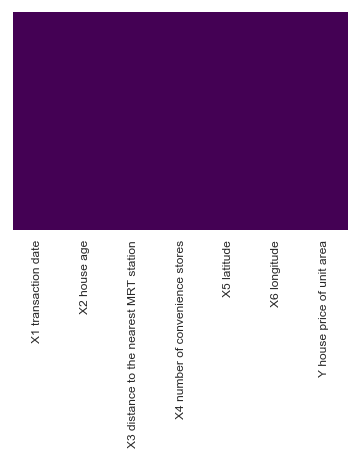

```python
# Draw a heatmap
sns.heatmap(raw_data.isnull(), cbar=False, yticklabels=False, cmap="viridis")
```

- Dataset has no missing values.

## 3.3 Looking for correlation

```python
# Compute the standard correlation coefficient
corr_matrix = raw_data.corr()
corr_matrix["Y house price of unit area"].sort_values(ascending=False)
# Observed that X1 and X2 has the least correlation with Y
# X3 (negative) and X4 (postive) has the highest correlation
```

```
Y house price of unit area                1.000000
X4 number of convenience stores           0.571005
X5 latitude                               0.546307
X6 longitude                              0.523287
X1 transaction date                       0.081545
X2 house age                             -0.210567
X3 distance to the nearest MRT station   -0.673613
Name: Y house price of unit area, dtype: float64
```

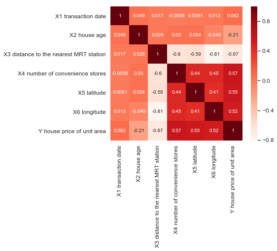

```python
plt.figure(figsize=(6,5))
sns.heatmap(corr_matrix, cmap="Reds", annot=True)
```

- Y has strongest negative correlation with X3 (shorter distance return higher price)
- Y has strongest positive correlation with X4, X5 & X6.
- X1 has almost no corelation with Y. We can infer there is no linear r/s between this predictor.

## 3.4 Exploring the PDFs

A great step in the data exploration is to display the probability distribution function (PDF) of a variable. The PDF will show us how that variable is distributed. This makes it very easy to spot anomalies, such as outliers.

### 3.4.1 Exploring variables (X1 - X6, Y)

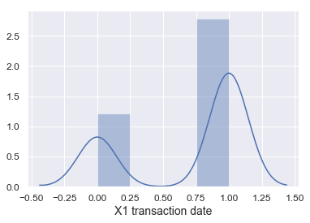

```python
sns.distplot(raw_data['X1 transaction date'])
```

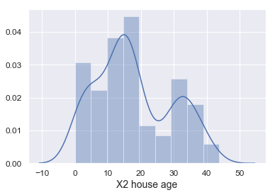

```python
sns.distplot(raw_data['X2 house age'])
```

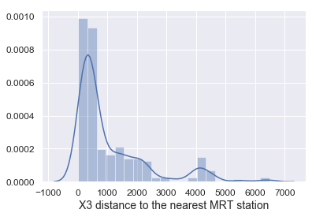

```python
sns.distplot(raw_data['X3 distance to the nearest MRT station'])
# Presence of outlier is observed in X3, we will deal it in 3.5
```

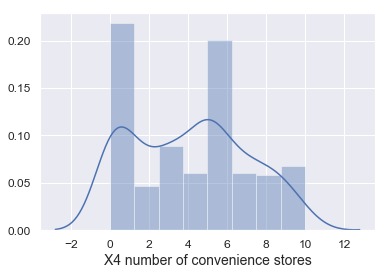

```python
sns.distplot(raw_data['X4 number of convenience stores'])
```

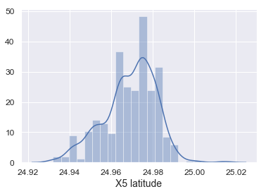

```python
sns.distplot(raw_data['X5 latitude'])
```

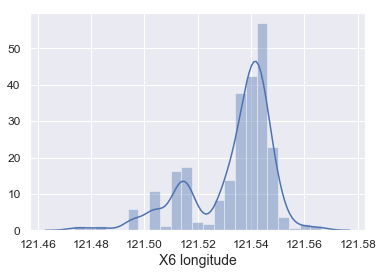

```python
sns.distplot(raw_data['X6 longitude'])
```

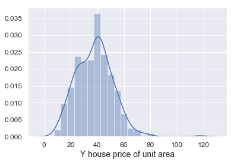

```python
sns.distplot(raw_data['Y house price of unit area'])
```

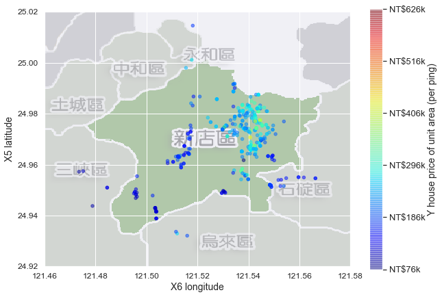

```python
# Visualize the distribution of house location and price
# Got a map image of Xindian distrcit
# https://zh.wikipedia.org/wiki/%E6%96%B0%E5%BA%97%E5%8D%80#/media/File:Xindian_District.PNG
# Then plot our observations into the map

import matplotlib.image as mpimg
xindian_img=mpimg.imread('Xindian_district.png')
ax = raw_data.plot(kind="scatter", x="X6 longitude", y="X5 latitude", figsize=(10,7),
                       c="Y house price of unit area", cmap=plt.get_cmap("jet"),
                       colorbar=False, alpha=0.5,
                      )
plt.imshow(xindian_img, extent=[121.46, 121.58, 24.92, 25.02], alpha=0.3,
           cmap=plt.get_cmap("jet"))
plt.ylabel("X5 latitude", fontsize=14)
plt.xlabel("X6 longitude", fontsize=14)

prices = raw_data["Y house price of unit area"]
tick_values = np.linspace(prices.min(), prices.max(),11)
cbar = plt.colorbar() # Plot a colorbar
cbar.ax.set_yticklabels(["NT$%dk"%(round(v*10)) for v in tick_values], fontsize=13)
cbar.set_label('Y house price of unit area (per ping)', fontsize=14)
```

It is worth to know that the house price in the east region of the district is more expensive

## 3.5 Dealing with outliers

To deal with the outliers in X3, we can deal with the problem easily by removing 0.5%, or 1% of the problematic samples.

```python
# Declare a variable that will be equal to the 99th percentile of the 'X3' variable
condition = raw_data['X3 distance to the nearest MRT station'].quantile(0.99)
# Create a new df, with the condition that all prices must be below the 99 percentile of 'X3'
raw_data_no_outliers= raw_data[raw_data['X3 distance to the nearest MRT station']<condition]
# Essentially removed the top 1% of the data about 'X3'
raw_data_no_outliers.describe(include='all')
# Data count decreased from 414 to 409, as we dropped 1%
```

|  | X1 transaction date | X2 house age | X3 distance to the nearest MRT station | X4 number of convenience stores | X5 latitude | X6 longitude | Y house price of unit area |
| --- | --- | --- | --- | --- | --- | --- | --- |
| count | 409.000000 | 409.000000 | 409.000000 | 409.000000 | 409.000000 | 409.000000 | 409.000000 |
| mean | 0.694377 | 17.612469 | 1023.261961 | 4.132029 | 24.969238 | 121.534022 | 38.262103 |
| std | 0.461235 | 11.401626 | 1142.384915 | 2.943450 | 0.012329 | 0.014211 | 13.442649 |
| min | 0.000000 | 0.000000 | 23.382840 | 0.000000 | 24.932070 | 121.495070 | 7.600000 |
| 25% | 0.000000 | 8.900000 | 289.324800 | 1.000000 | 24.963050 | 121.529810 | 28.400000 |
| 50% | 1.000000 | 16.000000 | 492.231300 | 4.000000 | 24.971510 | 121.538740 | 38.800000 |
| 75% | 1.000000 | 27.600000 | 1414.837000 | 6.000000 | 24.977950 | 121.543480 | 46.600000 |
| max | 1.000000 | 43.800000 | 4605.749000 | 10.000000 | 25.014590 | 121.566270 | 117.500000 |

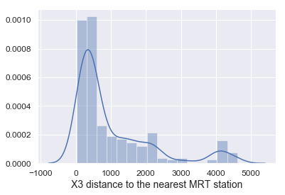

```python
sns.distplot(raw_data_no_outliers['X3 distance to the nearest MRT station'])
# Now X3 looks much better
```

```python
# Reset index for observations removed
data_cleaned = raw_data_no_outliers.reset_index(drop=True)
```

```python
data_cleaned.describe(include='all')
```

|  | X1 transaction date | X2 house age | X3 distance to the nearest MRT station | X4 number of convenience stores | X5 latitude | X6 longitude | Y house price of unit area |
| --- | --- | --- | --- | --- | --- | --- | --- |
| count | 409.000000 | 409.000000 | 409.000000 | 409.000000 | 409.000000 | 409.000000 | 409.000000 |
| mean | 0.694377 | 17.612469 | 1023.261961 | 4.132029 | 24.969238 | 121.534022 | 38.262103 |
| std | 0.461235 | 11.401626 | 1142.384915 | 2.943450 | 0.012329 | 0.014211 | 13.442649 |
| min | 0.000000 | 0.000000 | 23.382840 | 0.000000 | 24.932070 | 121.495070 | 7.600000 |
| 25% | 0.000000 | 8.900000 | 289.324800 | 1.000000 | 24.963050 | 121.529810 | 28.400000 |
| 50% | 1.000000 | 16.000000 | 492.231300 | 4.000000 | 24.971510 | 121.538740 | 38.800000 |
| 75% | 1.000000 | 27.600000 | 1414.837000 | 6.000000 | 24.977950 | 121.543480 | 46.600000 |
| max | 1.000000 | 43.800000 | 4605.749000 | 10.000000 | 25.014590 | 121.566270 | 117.500000 |

## 3.6 Log transformation

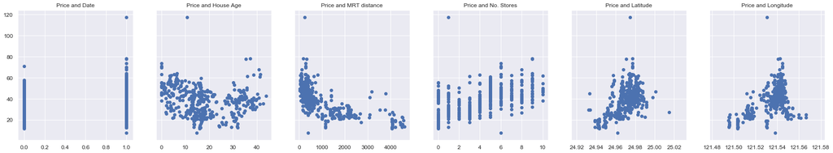

```python
# Check the plot between X and Y
f, (ax1, ax2, ax3, ax4, ax5, ax6) = plt.subplots(1, 6, sharey=True, figsize =(30,5))
ax1.scatter(data_cleaned['X1 transaction date'],data_cleaned['Y house price of unit area'])
ax1.set_title('Price and Date')
ax2.scatter(data_cleaned['X2 house age'],data_cleaned['Y house price of unit area'])
ax2.set_title('Price and House Age')
ax3.scatter(data_cleaned['X3 distance to the nearest MRT station'],data_cleaned['Y house price of unit area'])
ax3.set_title('Price and MRT distance')
ax4.scatter(data_cleaned['X4 number of convenience stores'],data_cleaned['Y house price of unit area'])
ax4.set_title('Price and No. Stores')
ax5.scatter(data_cleaned['X5 latitude'],data_cleaned['Y house price of unit area'])
ax5.set_title('Price and Latitude')
ax6.scatter(data_cleaned['X6 longitude'],data_cleaned['Y house price of unit area'])
ax6.set_title('Price and Longitude')
plt.show()
```

```python
# Let's transform X & Y with a log transformation
log_price = np.log(data_cleaned['Y house price of unit area'])
log_distance = np.log(data_cleaned['X3 distance to the nearest MRT station'])

# Add them to our data frame
data_cleaned['X3 log distance to the nearest MRT station'] = log_distance
data_cleaned['Y log house price of unit area'] = log_price

# Drop original Y and X3
data_cleaned = data_cleaned.drop(['Y house price of unit area'],axis=1)
data_cleaned = data_cleaned.drop(['X3 distance to the nearest MRT station'],axis=1)

data_cleaned.head()
```

|  | X1 transaction date | X2 house age | X4 number of convenience stores | X5 latitude | X6 longitude | X3 log distance to the nearest MRT station | Y log house price of unit area |
| --- | --- | --- | --- | --- | --- | --- | --- |
| 0 | 0 | 32.0 | 10 | 24.98298 | 121.54024 | 4.441225 | 3.634951 |
| 1 | 0 | 19.5 | 9 | 24.98034 | 121.53951 | 5.725527 | 3.742420 |
| 2 | 1 | 13.3 | 5 | 24.98746 | 121.54391 | 6.331474 | 3.856510 |
| 3 | 1 | 13.3 | 5 | 24.98746 | 121.54391 | 6.331474 | 4.003690 |
| 4 | 0 | 5.0 | 5 | 24.97937 | 121.54245 | 5.967603 | 3.763523 |

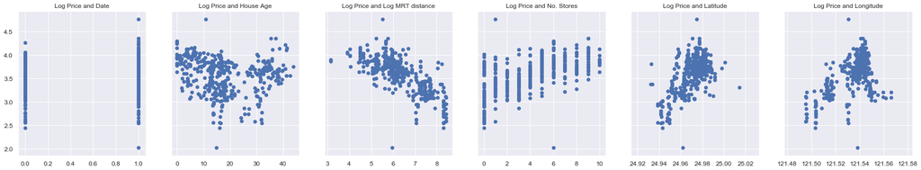

```python
# Check the plot between X and Y again
f, (ax1, ax2, ax3, ax4, ax5, ax6) = plt.subplots(1, 6, sharey=True, figsize =(30,5))
ax1.scatter(data_cleaned['X1 transaction date'],data_cleaned['Y log house price of unit area'])
ax1.set_title('Log Price and Date')
ax2.scatter(data_cleaned['X2 house age'],data_cleaned['Y log house price of unit area'])
ax2.set_title('Log Price and House Age')
ax3.scatter(data_cleaned['X3 log distance to the nearest MRT station'],data_cleaned['Y log house price of unit area'])
ax3.set_title('Log Price and Log MRT distance')
ax4.scatter(data_cleaned['X4 number of convenience stores'],data_cleaned['Y log house price of unit area'])
ax4.set_title('Log Price and No. Stores')
ax5.scatter(data_cleaned['X5 latitude'],data_cleaned['Y log house price of unit area'])
ax5.set_title('Log Price and Latitude')
ax6.scatter(data_cleaned['X6 longitude'],data_cleaned['Y log house price of unit area'])
ax6.set_title('Log Price and Longitude')
plt.show()
# Price vs X3 seems like a good linear regression material
```